# Portfolio VaR and Stress Testing

The same results `main.py` prints, with commentary alongside each one.

This notebook imports the modules and repeats no logic. Every calculation lives in `data.py`, `risk.py`, and `scenarios.py`.

Run all cells.

```python
import numpy as np
import pandas as pd

import config, main, plots, risk
import scenarios as sc
from data import fetch_prices, compute_returns, portfolio_returns, weights_array

pd.set_option('display.float_format', lambda v: f'{v:,.4f}')
```

## 1. The data

Daily adjusted close from Yahoo Finance, cached in `data/prices.csv`.

A return is `(price_today / price_yesterday) - 1`. The first day has no prior day, so 1,255 prices give 1,254 returns.

```python
prices  = fetch_prices(config.TICKERS, config.START_DATE, config.END_DATE,
                       cache_path=config.PRICE_CACHE)
returns = compute_returns(prices)

print(f'{len(prices):,} prices -> {len(returns):,} returns')
print(f'{prices.index.min():%Y-%m-%d} to {prices.index.max():%Y-%m-%d}')
prices.tail(3)
```

```
1,255 prices -> 1,254 returns
2021-08-30 to 2026-08-28
```

| Date | AAPL | GOOGL | MSFT |
| --- | --- | --- | --- |
| 2026-08-26 | 313.4500 | 342.0000 | 496.3700 |
| 2026-08-27 | 314.5800 | 340.6500 | 505.0600 |
| 2026-08-28 | 319.7000 | 346.5900 | 513.5300 |

## 2. Market statistics

**Volatility** is the standard deviation of returns. **Correlation** measures how each pair moves together.

```python
stats = pd.DataFrame({'volatility %': returns.std()*100,
                      'mean return %': returns.mean()*100})
display(stats)
display(returns.corr())
```

|  | volatility % | mean return % |
| --- | --- | --- |
| AAPL | 1.7656 | 0.0762 |
| GOOGL | 2.0229 | 0.0908 |
| MSFT | 1.7733 | 0.0608 |

|  | AAPL | GOOGL | MSFT |
| --- | --- | --- | --- |
| AAPL | 1.0000 | 0.5170 | 0.5311 |
| GOOGL | 0.5170 | 1.0000 | 0.5476 |
| MSFT | 0.5311 | 0.5476 | 1.0000 |

## 3. Portfolio aggregation and diversification

The portfolio return is the weighted sum of the stock returns. This is exact for simple returns, which is why the project does not use log returns.

The portfolio is **calmer than the weighted average of its parts**. That gap is diversification, and it comes from the pair terms in `w' Sigma w`.

```python
w   = weights_array(config.WEIGHTS, config.TICKERS)
pr  = portfolio_returns(returns, config.WEIGHTS)
cov = risk.covariance_matrix(returns)
vol = risk.portfolio_volatility(cov, w)

naive = float(w @ returns.std().to_numpy())
print(f'weighted-average volatility  {naive*100:.4f} %   <- the wrong answer')
print(f'true portfolio volatility    {vol*100:.4f} %')
print(f'diversification gain         {(naive-vol)*100:.4f} % lower')

# Proof: with every correlation at 1.0, the naive answer becomes correct.
vols = sc.volatilities(cov)
perfect = sc.rebuild_covariance(vols, pd.DataFrame(np.ones((3,3)), index=cov.index, columns=cov.columns))
print(f'\nvolatility if all correlations = 1.0: {risk.portfolio_volatility(perfect, w)*100:.4f} %')
```

```
weighted-average volatility  1.8576 %   <- the wrong answer
true portfolio volatility    1.5459 %
diversification gain         0.3116 % lower

volatility if all correlations = 1.0: 1.8576 %
```

## 4. Part A — Value at Risk

> With 95% confidence, the 1-day loss will not exceed the figure below. Equivalently: on the worst 5% of days, the loss is larger than it.

**Expected Shortfall** is the average loss across those worst days. It answers the question VaR leaves open, and it is always the larger number.

```python
results = main.build_results(returns)
results['results']
```

|  | VaR 95% | ES 95% | VaR 99% | ES 99% |
| --- | --- | --- | --- | --- |
| Historical | 25,216.6412 | 33,971.8097 | 38,113.0991 | 47,181.9339 |
| Parametric | 25,428.4324 | 31,888.2802 | 35,963.9173 | 41,202.5840 |
| Monte Carlo | 24,657.4164 | 31,236.7466 | 35,312.8430 | 40,755.5910 |

### The correctness check

Monte Carlo and parametric share the same covariance matrix and the same normal assumption. One solves a formula; the other rolls 100,000 dice. **They must agree.**

The assignment specifies Method 2 without a mean and Method 3 *with* a mean vector, so they differ slightly by design. Zeroing the Monte Carlo mean removes that difference.

```python
for c in config.CONFIDENCE_LEVELS:
    p = results['results'].loc['Parametric', f'VaR {c:.0%}']
    z = results['mc_zero_mean_var'][c]
    print(f'{c:.0%}  parametric ${p:>9,.0f}   MC zero-mean ${z:>9,.0f}   gap {abs(z-p)/p:.2%}')

drift = float(w @ returns.mean().to_numpy()) * config.PORTFOLIO_VALUE
mc_sample = results['results'].loc['Monte Carlo', 'VaR 95%']
print(f'\nportfolio mean daily return is ${drift:,.0f} on ${config.PORTFOLIO_VALUE:,.0f}')
print(f'and that is exactly the gap between the two Monte Carlo variants:')
print(f'  ${results["mc_zero_mean_var"][0.95]:,.0f} - ${mc_sample:,.0f} = ${results["mc_zero_mean_var"][0.95]-mc_sample:,.0f}')
```

```
95%  parametric $   25,428   MC zero-mean $   25,432   gap 0.02%
99%  parametric $   35,964   MC zero-mean $   36,088   gap 0.34%

portfolio mean daily return is $775 on $1,000,000
and that is exactly the gap between the two Monte Carlo variants:
  $25,432 - $24,657 = $775
```

### Fat tails

At 95% the three methods agree closely. At 99% they separate. The normal curve does not allow for how often extreme days really happen.

**The normal assumption is fine in the middle and wrong in the tail — exactly where a risk number has to work.**

```python
r = results['results']
for measure in ['VaR 99%', 'ES 99%']:
    h, p = r.loc['Historical', measure], r.loc['Parametric', measure]
    print(f'{measure}:  historical ${h:>9,.0f}   parametric ${p:>9,.0f}   '
          f'short by ${h-p:>7,.0f}  ({h/p-1:.1%})')
```

```
VaR 99%:  historical $   38,113   parametric $   35,964   short by $  2,149  (6.0%)
ES 99%:  historical $   47,182   parametric $   41,203   short by $  5,979  (14.5%)
```

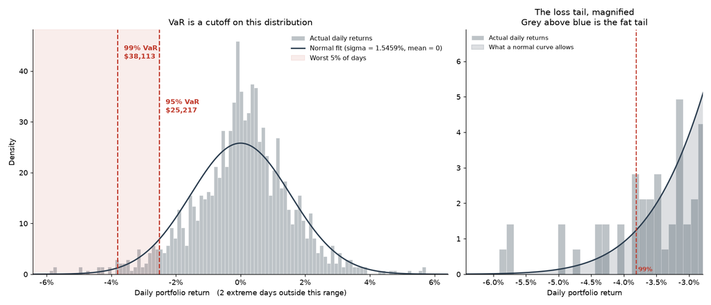

```python
_ = plots.plot_return_distribution(pr,
        {c: r.loc['Historical', f'VaR {c:.0%}'] for c in config.CONFIDENCE_LEVELS},
        config.PORTFOLIO_VALUE, config.PLOTS_DIR / '1_return_distribution.png')
from IPython.display import Image, display
display(Image(str(config.PLOTS_DIR / '1_return_distribution.png')))
```

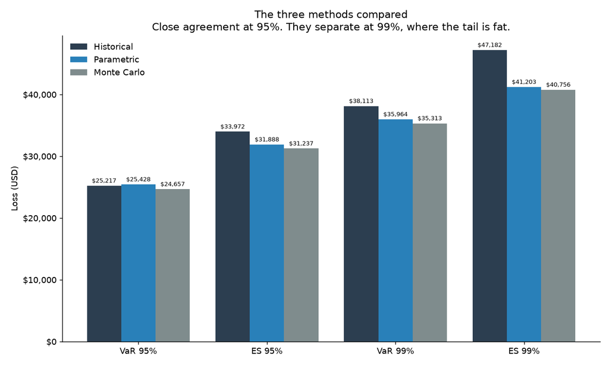

```python
_ = plots.plot_method_comparison(r, config.PLOTS_DIR / '2_method_comparison.png')
display(Image(str(config.PLOTS_DIR / '2_method_comparison.png')))
```

## 5. Part B — Stress tests

A stress test is not statistical. VaR reads history and reports a probability. A stress test asks a direct question with no probability: *this happens, what do I lose?*

That matters because VaR cannot warn about an event outside its data window. This window starts in 2021, so it holds no 2008 and no COVID crash.

```python
for s in results['scenarios']:
    print(f'{s.name:<28} {s.portfolio_return:>8.2%}   loss ${s.loss:>10,.0f}')

worst = r.loc['Parametric', 'VaR 99%']
print(f'\nfor comparison, 99% VaR is ${worst:,.0f}')
for s in results['scenarios']:
    print(f'  {s.name:<28} is {s.loss/worst:.1f}x the 99% VaR')
```

```
2008-style equity shock        -7.15%   loss $    71,500
Tech drawdown                 -10.00%   loss $   100,000

for comparison, 99% VaR is $35,964
  2008-style equity shock      is 2.0x the 99% VaR
  Tech drawdown                is 2.8x the 99% VaR
```

### Scenario 3 — correlation spike

Volatilities are held fixed. Every pairwise correlation is forced to 0.85.

**No stock becomes riskier.** Risk rises purely because the stocks begin moving together. In a crisis, correlations run toward 1 and diversification stops working — precisely when it is needed.

```python
base_vols     = sc.volatilities(cov)
stressed_cov  = sc.spike_correlations(cov, config.STRESSED_CORRELATION)
stressed_vols = sc.volatilities(stressed_cov)

print('per-stock volatility unchanged:', np.allclose(base_vols, stressed_vols))
print(f'  base     {np.round(base_vols*100, 4)}')
print(f'  stressed {np.round(stressed_vols*100, 4)}')
print(f'\nportfolio volatility  {vol*100:.4f} %  ->  {results["stressed_volatility"]*100:.4f} %\n')

for c in config.CONFIDENCE_LEVELS:
    b, s_ = r.loc['Parametric', f'VaR {c:.0%}'], results['stressed_var'][c]
    print(f'parametric VaR {c:.0%}   ${b:>9,.0f}  ->  ${s_:>9,.0f}   (+{(s_/b-1)*100:.1f} %)')

print('\nThe increase is the same at both levels because parametric VaR is')
print('linear in volatility, so z cancels in the ratio:')
print(f'  {results["stressed_volatility"]*100:.4f} / {vol*100:.4f} = {results["stressed_volatility"]/vol:.3f}')
```

```
per-stock volatility unchanged: True
  base     [1.7656 2.0229 1.7733]
  stressed [1.7656 2.0229 1.7733]

portfolio volatility  1.5459 %  ->  1.7642 %

parametric VaR 95%   $   25,428  ->  $   29,019   (+14.1 %)
parametric VaR 99%   $   35,964  ->  $   41,042   (+14.1 %)

The increase is the same at both levels because parametric VaR is
linear in volatility, so z cancels in the ratio:
  1.7642 / 1.5459 = 1.141
```

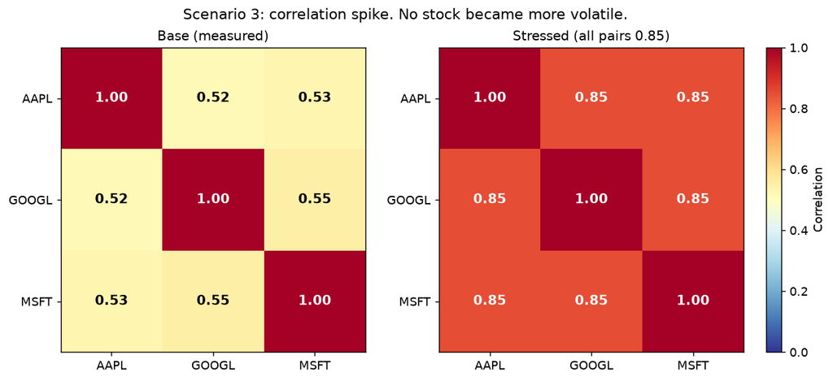

```python
_ = plots.plot_correlation_shift(results['base_correlation'], results['stressed_correlation'],
                                 config.PLOTS_DIR / '3_correlation_spike.png')
display(Image(str(config.PLOTS_DIR / '3_correlation_spike.png')))
```

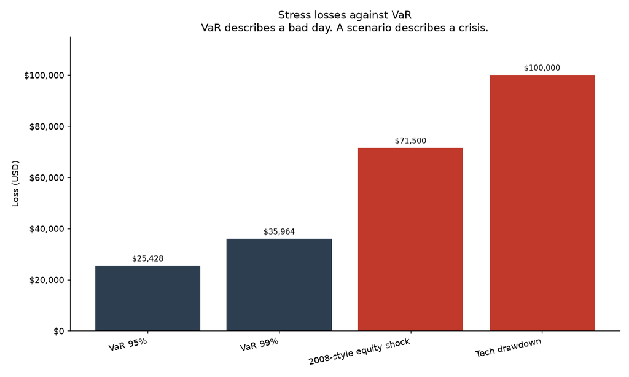

```python
_ = plots.plot_scenarios_vs_var(
        {c: r.loc['Parametric', f'VaR {c:.0%}'] for c in config.CONFIDENCE_LEVELS},
        {s.name: s.loss for s in results['scenarios']},
        config.PLOTS_DIR / '4_scenarios_vs_var.png')
display(Image(str(config.PLOTS_DIR / '4_scenarios_vs_var.png')))
```

## 6. Assumptions and limitations

| Assumption | Applies to | Why it may be wrong |
| --- | --- | --- |
| Returns are normal | Parametric, Monte Carlo | Real returns have fat tails. The 99% loss is understated. |
| The past predicts the future | Historical | This window holds no 2008 and no COVID crash. |
| Mean daily return is zero | Parametric | A deliberate simplification, per the assignment's formula. |
| Correlations are stable | Parametric, Monte Carlo | They are not. Scenario 3 quantifies the effect. |
| Weights stay fixed | All | A real portfolio drifts unless rebalanced. |
| One day, position can be exited | All | Says nothing about a week-long slide. |
| Every past day counts equally | Historical | A quiet day gets the same weight as a panic day. |
| The shock sizes are right | Scenarios 1-3 | Chosen by judgment. A stress test gives the consequence of an assumption, never its odds. |